# Lab 02 - Plastic waste

Negar Maleki

01/28/2022

## Load packages and data

```r
# Load the tidyverse package
library(tidyverse)
```

```r
plastic_waste <- read.csv(here::here("data/plastic-waste.csv"))
```

## Exercises

### Exercise 1

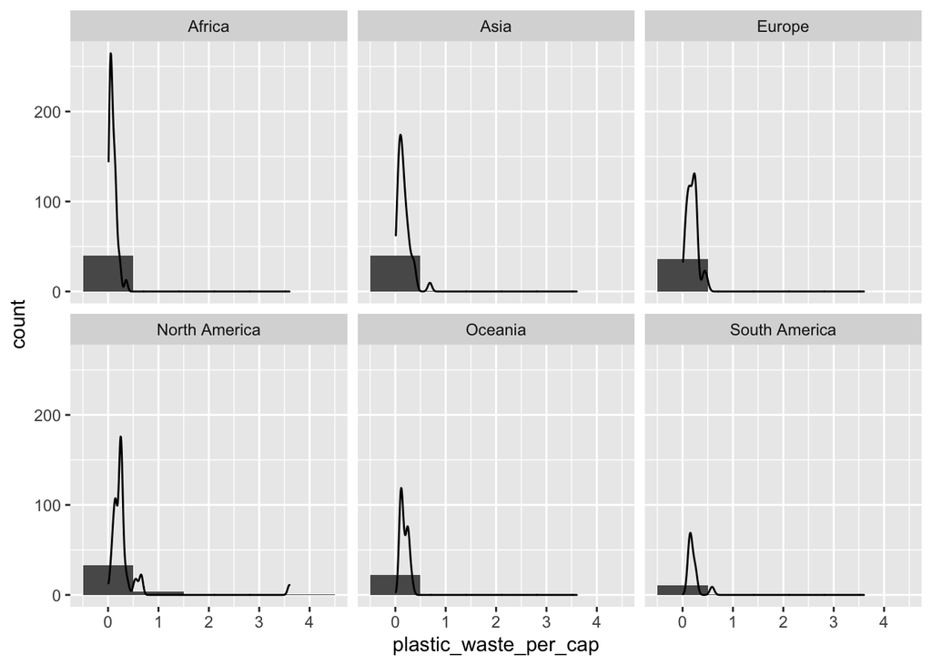

```r
# 1-1
hist_1 <- ggplot(plastic_waste) +
  aes(x = plastic_waste_per_cap) +
  geom_histogram(binwidth = 1) +
  facet_wrap(~continent)

hist_1 +
  geom_density(aes(y = after_stat(count)))
```

### Exercise 2

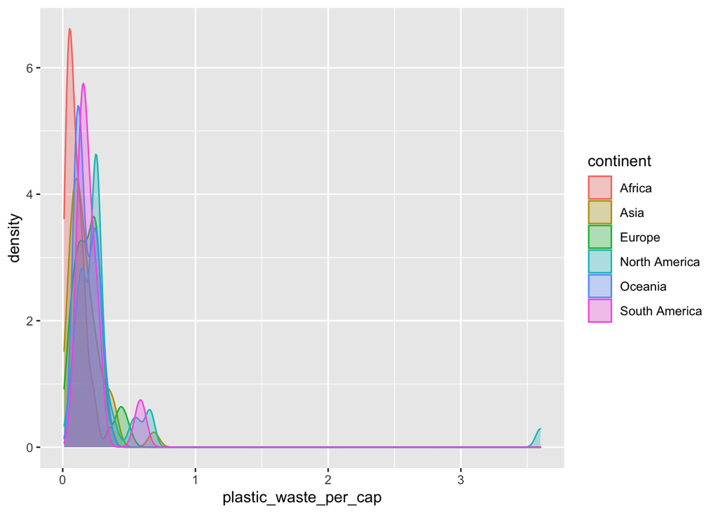

```r
# insert code here
ggplot(plastic_waste) +
  aes(x = plastic_waste_per_cap, color=continent, fill=continent) +
  geom_density(alpha=0.3)
```

### Exercise 3

When specified inside aes, an aesthetic is mapped to the value of a variable in the data. Since there is a mapping between the data and the visible aesthetic, there is a legend which shows that mapping. Outside of an aes call, the aesthetic is just set to a specific value.

### Exercise 4

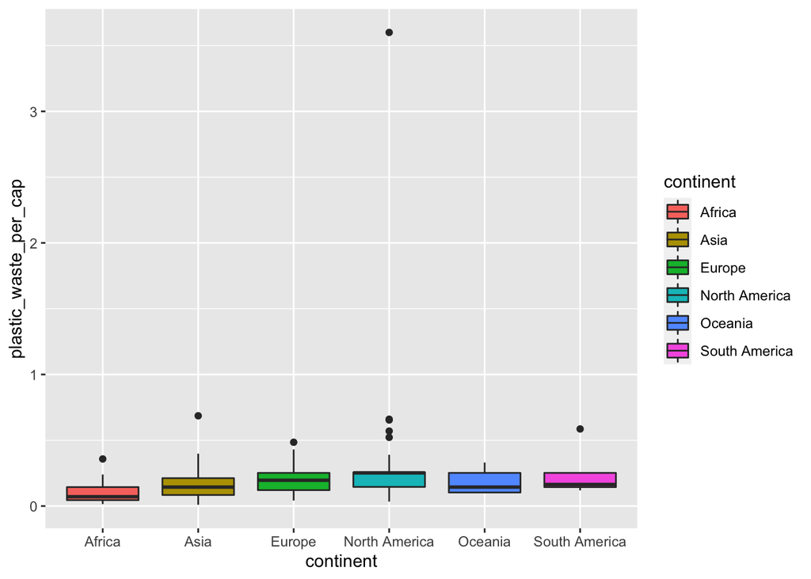

```r
p <- ggplot(plastic_waste) +
  aes(x = continent, y = plastic_waste_per_cap, fill=continent) +
  geom_boxplot()
p
```

### Exercise 5

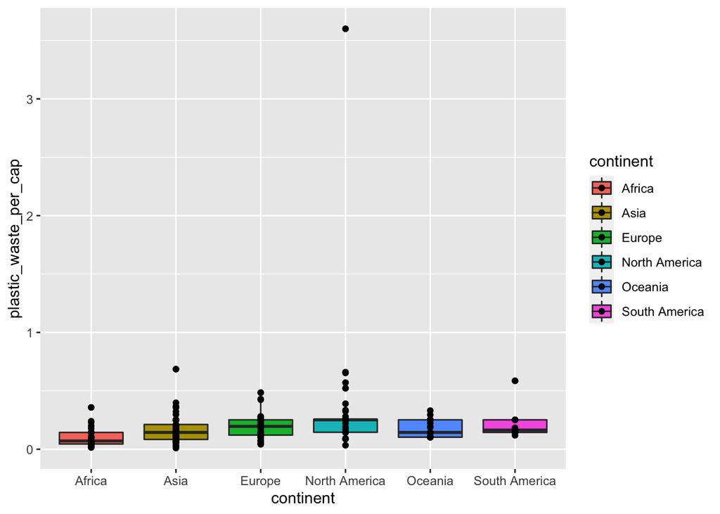

```r
p +
  geom_point()
```

### Exercise 6

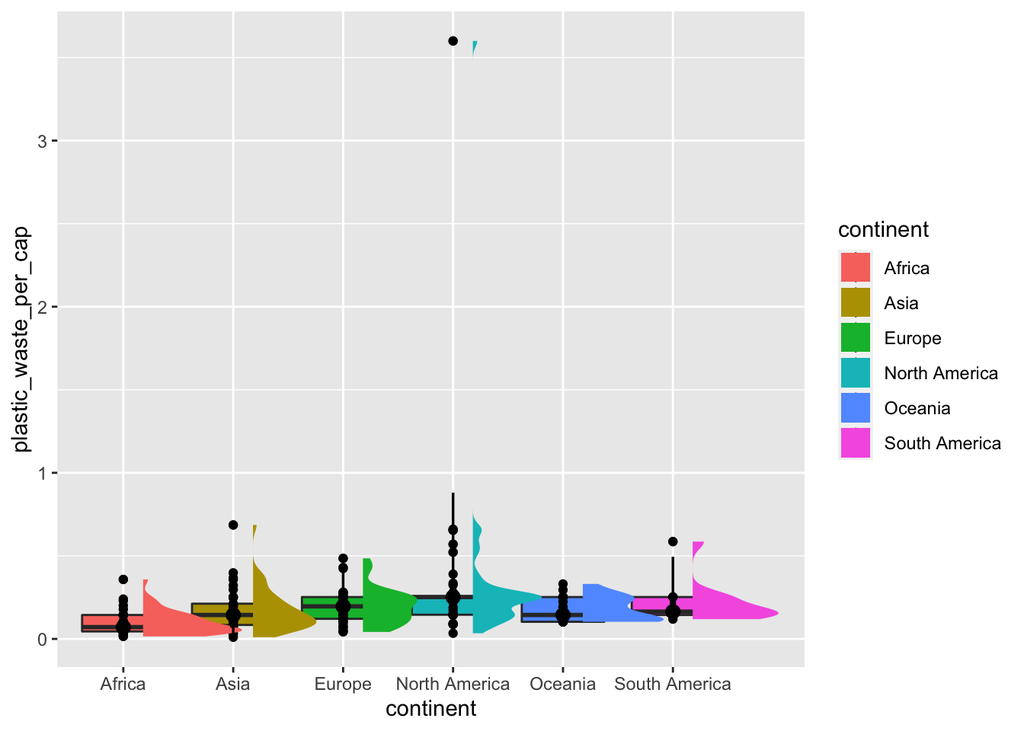

```r
p +
  geom_point() +
  ggdist::stat_halfeye(justification = -.2)
```

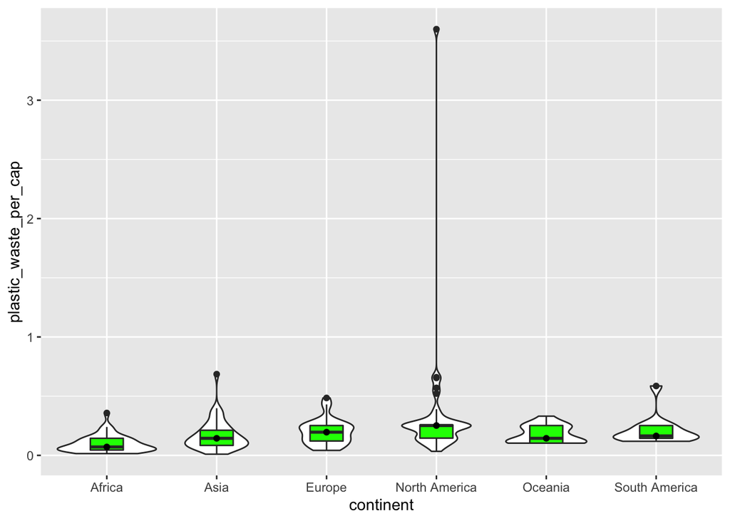

```r
t <- ggplot(data = plastic_waste,
       mapping = aes(x = continent,
                     y = plastic_waste_per_cap)) +
  geom_violin()+
  geom_boxplot(width=.3, fill="green") +
  stat_summary(fun.y=median, geom="point")
t
```

### Exercise 7

#### What does the density or data points show that the boxplot does not?

Distribution of other data out of box plot.